# NYC Motor Vehicle Collisions

## Spring 2026 Data Science Project

**Miskay Zelalem, Dinna Yeshitlla, Emmanuel Michael, Emmanuel Adedeji, Daniel Odetoye**

**Contributions**

[output not shown]

## Libraries used

This tutorial relies on the following open-source Python libraries. The block below loads everything once at the top of the notebook so individual sections can stay focused on analysis.

- [**pandas**](https://pandas.pydata.org/docs/) — DataFrame manipulation and CSV ingest.
- [**NumPy**](https://numpy.org/doc/) — numerical arrays, broadcasting, percentiles.
- [**Matplotlib**](https://matplotlib.org/stable/) — primary plotting backend.
- [**seaborn**](https://seaborn.pydata.org/) — high-level statistical visualizations (heatmaps, classification report).
- [**SciPy**](https://docs.scipy.org/doc/scipy/) — Welch's t-test (`scipy.stats.ttest_ind`) for the night-vs-day hypothesis test.
- [**scikit-learn**](https://scikit-learn.org/stable/) — `train_test_split`, `LabelEncoder`, `Pipeline`, `LogisticRegression`, `RandomForestClassifier`, plus the metrics in `sklearn.metrics`.

```python
# ── Core data stack ──
import pandas as pd
import numpy as np

# ── Plotting ──
import matplotlib.pyplot as plt
import matplotlib.ticker as ticker
import seaborn as sns
%matplotlib inline
plt.style.use('seaborn-v0_8-whitegrid')

# ── Statistics ──
from scipy import stats

# ── Machine learning (scikit-learn) ──
from sklearn.model_selection import train_test_split
from sklearn.preprocessing import LabelEncoder, StandardScaler
from sklearn.pipeline import Pipeline
from sklearn.linear_model import LogisticRegression
from sklearn.ensemble import RandomForestClassifier
from sklearn.metrics import (
    accuracy_score, classification_report,
    confusion_matrix, roc_auc_score, roc_curve
)

# Suppress non-actionable warnings (e.g. SettingWithCopyWarning during
# label encoding) so the rendered tutorial stays readable.
import warnings
warnings.filterwarnings('ignore')
```

# I. INTRODUCTION

New York City is one of the busiest cities in the world, with millions of cars, pedestrians, and cyclists sharing the streets every day. Because of that, traffic accidents happen often, and the NYPD is required to file a report for every reported collision in the five boroughs. These reports go back to 2012 and are published on NYC Open Data. The result is a public record of more than two million crashes, including when they happened, where they happened, who was hurt, and what the responding officer thought caused the crash.

We picked this dataset because the patterns inside it can actually tell us something useful about traffic safety in NYC. If some boroughs have way more severe crashes than others, that could point to issues with the roads or how laws are enforced in those areas. If nighttime crashes turn out to be more dangerous than daytime ones, that could matter for things like street lighting and DUI policy. NYC has actually made traffic safety a priority through its Vision Zero initiative, which has the goal of eliminating traffic deaths in the city, so this kind of analysis felt relevant.

Our analysis is built around three main questions. First, where and when do crashes happen, and how are they spread out across the city? Are some boroughs or times of day way more represented than others? Second, are nighttime crashes actually more severe than daytime crashes, or is that just a common assumption? And third, can we predict whether a crash will result in an injury based on things like the borough, time of day, contributing factor, and vehicle type? The first two questions are answered through our exploratory data analysis and a hypothesis test, and the third one is what our machine learning section is built around.

# II. DATA CURATION

Our data comes from the Motor Vehicle Collisions: Crashes dataset on NYC Open Data, published by the NYPD. It gets updated regularly and contains every motor vehicle collision in NYC where the NYPD filed a report (form MV-104AN), which is required whenever a crash involves an injury, a fatality, or at least $1,000 in property damage. The version we downloaded had 2,252,143 rows and 29 columns. The columns cover when the crash happened (date and time), where it happened (borough, ZIP code, latitude, longitude, and street names), how severe it was (injury and fatality counts broken out by pedestrians, cyclists, and motorists), and what was involved (up to five contributing factors and vehicle types per crash).

Before we could analyze anything, we had to clean the data up. Pandas reads everything in as strings by default, so we converted the columns we cared about into the right types. The crash date and crash time were parsed into pandas datetime objects so we could pull things like the hour of day and the month. The injury and fatality counts and the latitude/longitude were converted to numeric. For all of these conversions we passed errors='coerce' so that any bad entries got turned into NaN or NaT instead of crashing the whole thing, which was important since with over 2 million rows there were almost definitely going to be some bad entries. The pandas docs for read_csv cover the gotchas around dtype inference on large files in more detail.

After parsing, we cut the data down to the 10 columns we actually needed: crash date, crash time, borough, ZIP code, latitude, longitude, persons injured, persons killed, the first contributing factor, and the first vehicle type. We dropped rows that were missing a borough value, since most of those were highway crashes (like ones on the BQE) where the officer didn't fill in a borough, and borough is one of the main things we wanted to look at. We also added two helper columns: HOUR (the hour of day, used for the night vs. day comparison and as a model feature) and MONTH (used to check for seasonal patterns). The result is a cleaned DataFrame called crash_df that we used for the rest of the analysis. We did keep the original DataFrame around in case any later analysis needed the dropped rows or the columns we left out.

One thing worth mentioning is that we didn't drop the extreme outlier rows (like crashes with 40 or more injured people) up front, since part of our exploratory analysis was actually looking at those extreme cases. We handled them later by capping histograms and using log scales where it helped, and by setting up the ML target as a binary "any injury" outcome instead of trying to predict the raw injury count.

DATA PREPROCESSING

a) Import

```python
df = pd.read_csv("Motor_Vehicle_Collisions_-_Crashes_20260401.csv", low_memory=False)
df.shape
```

```
(2252143, 29)
```

b) Parse

```python
# Parsing: Date & Time
df['CRASH DATE'] = pd.to_datetime(df['CRASH DATE'], errors='coerce')
df['CRASH TIME'] = pd.to_datetime(df['CRASH TIME'], format='%H:%M', errors='coerce')

df[['CRASH DATE', 'CRASH TIME']].head()
```

|  | CRASH DATE | CRASH TIME |
| --- | --- | --- |
| 0 | 2021-09-11 | 1900-01-01 02:39:00 |
| 1 | 2022-03-26 | 1900-01-01 11:45:00 |
| 2 | 2023-11-01 | 1900-01-01 01:29:00 |
| 3 | 2022-06-29 | 1900-01-01 06:55:00 |
| 4 | 2022-09-21 | 1900-01-01 13:21:00 |

```python
# Parsing: Number columns
num_cols = [
    'NUMBER OF PERSONS INJURED',
    'NUMBER OF PERSONS KILLED',
    'NUMBER OF PEDESTRIANS INJURED',
    'NUMBER OF PEDESTRIANS KILLED',
    'NUMBER OF CYCLIST INJURED',
    'NUMBER OF CYCLIST KILLED',
    'NUMBER OF MOTORIST INJURED',
    'NUMBER OF MOTORIST KILLED',
    'LATITUDE',
    'LONGITUDE'
]

for col in num_cols:
    df[col] = pd.to_numeric(df[col], errors='coerce')
df[num_cols].head()
```

|  | NUMBER OF PERSONS INJURED | NUMBER OF PERSONS KILLED | NUMBER OF PEDESTRIANS INJURED | NUMBER OF PEDESTRIANS KILLED | NUMBER OF CYCLIST INJURED | NUMBER OF CYCLIST KILLED | NUMBER OF MOTORIST INJURED | NUMBER OF MOTORIST KILLED | LATITUDE | LONGITUDE |
| --- | --- | --- | --- | --- | --- | --- | --- | --- | --- | --- |
| 0 | 2.0 | 0.0 | 0 | 0 | 0 | 0 | 2 | 0 | NaN | NaN |
| 1 | 1.0 | 0.0 | 0 | 0 | 0 | 0 | 1 | 0 | NaN | NaN |
| 2 | 1.0 | 0.0 | 0 | 0 | 0 | 0 | 1 | 0 | 40.62179 | -73.970024 |
| 3 | 0.0 | 0.0 | 0 | 0 | 0 | 0 | 0 | 0 | NaN | NaN |
| 4 | 0.0 | 0.0 | 0 | 0 | 0 | 0 | 0 | 0 | NaN | NaN |

```python
df.dtypes[['CRASH DATE', 'CRASH TIME'] + num_cols]
```

```
CRASH DATE                       datetime64[ns]
CRASH TIME                       datetime64[ns]
NUMBER OF PERSONS INJURED               float64
NUMBER OF PERSONS KILLED                float64
NUMBER OF PEDESTRIANS INJURED             int64
NUMBER OF PEDESTRIANS KILLED              int64
NUMBER OF CYCLIST INJURED                 int64
NUMBER OF CYCLIST KILLED                  int64
NUMBER OF MOTORIST INJURED                int64
NUMBER OF MOTORIST KILLED                 int64
LATITUDE                                float64
LONGITUDE                               float64
dtype: object
```

c) Organize

```python
# Organizing
cols_keep = [
    'CRASH DATE',
    'CRASH TIME',
    'BOROUGH',
    'ZIP CODE',
    'LATITUDE',
    'LONGITUDE',
    'NUMBER OF PERSONS INJURED',
    'NUMBER OF PERSONS KILLED',
    'CONTRIBUTING FACTOR VEHICLE 1',
    'VEHICLE TYPE CODE 1'
]

crash_df = df[cols_keep].copy()
crash_df = crash_df.dropna(subset=['BOROUGH'])
crash_df['HOUR'] = crash_df['CRASH TIME'].dt.hour
crash_df['MONTH'] = crash_df['CRASH DATE'].dt.month

crash_df.head()
```

|  | CRASH DATE | CRASH TIME | BOROUGH | ZIP CODE | LATITUDE | LONGITUDE | NUMBER OF PERSONS INJURED | NUMBER OF PERSONS KILLED | CONTRIBUTING FACTOR VEHICLE 1 | VEHICLE TYPE CODE 1 | HOUR | MONTH |
| --- | --- | --- | --- | --- | --- | --- | --- | --- | --- | --- | --- | --- |
| 2 | 2023-11-01 | 1900-01-01 01:29:00 | BROOKLYN | 11230 | 40.621790 | -73.970024 | 1.0 | 0.0 | Unspecified | Moped | 1 | 11 |
| 9 | 2021-09-11 | 1900-01-01 09:35:00 | BROOKLYN | 11208 | 40.667202 | -73.866500 | 0.0 | 0.0 | Unspecified | Sedan | 9 | 9 |
| 10 | 2021-12-14 | 1900-01-01 08:13:00 | BROOKLYN | 11233 | 40.683304 | -73.917274 | 0.0 | 0.0 | NaN | NaN | 8 | 12 |
| 13 | 2021-12-14 | 1900-01-01 08:17:00 | BRONX | 10475 | 40.868160 | -73.831480 | 2.0 | 0.0 | Unspecified | Sedan | 8 | 12 |
| 14 | 2021-12-14 | 1900-01-01 21:10:00 | BROOKLYN | 11207 | 40.671720 | -73.897100 | 0.0 | 0.0 | Driver Inexperience | Sedan | 21 | 12 |

```python
crash_df.shape
```

```
(1564912, 12)
```

# III. EXPLORATORY DATA ANALYSIS

This section explores the cleaned crash dataset before we build any machine learning model. The goal is to understand **where crashes happen**, **when they happen**, and **how severe they are**. These patterns help justify the later modeling decision to predict whether a crash results in at least one injury.

For this analysis, we use the cleaned `crash_df` created during preprocessing because it already contains parsed date/time fields, numeric injury counts, borough information, and helper columns such as `HOUR` and `MONTH`.

```python
eda_df = crash_df.copy()
eda_df['NUMBER OF PERSONS INJURED'] = pd.to_numeric(
    eda_df['NUMBER OF PERSONS INJURED'], errors='coerce'
)
eda_df['NUMBER OF PERSONS KILLED'] = pd.to_numeric(
    eda_df['NUMBER OF PERSONS KILLED'], errors='coerce'
)
eda_df['HOUR'] = pd.to_numeric(eda_df['HOUR'], errors='coerce')
eda_df['MONTH'] = pd.to_numeric(eda_df['MONTH'], errors='coerce')

print(f"Cleaned rows used for EDA: {eda_df.shape[0]:,}")
print(f"Columns used for EDA: {eda_df.shape[1]:,}")
eda_df.head()
```

```
Cleaned rows used for EDA: 1,564,912
Columns used for EDA: 12
```

|  | CRASH DATE | CRASH TIME | BOROUGH | ZIP CODE | LATITUDE | LONGITUDE | NUMBER OF PERSONS INJURED | NUMBER OF PERSONS KILLED | CONTRIBUTING FACTOR VEHICLE 1 | VEHICLE TYPE CODE 1 | HOUR | MONTH |
| --- | --- | --- | --- | --- | --- | --- | --- | --- | --- | --- | --- | --- |
| 2 | 2023-11-01 | 1900-01-01 01:29:00 | BROOKLYN | 11230 | 40.621790 | -73.970024 | 1.0 | 0.0 | Unspecified | Moped | 1 | 11 |
| 9 | 2021-09-11 | 1900-01-01 09:35:00 | BROOKLYN | 11208 | 40.667202 | -73.866500 | 0.0 | 0.0 | Unspecified | Sedan | 9 | 9 |
| 10 | 2021-12-14 | 1900-01-01 08:13:00 | BROOKLYN | 11233 | 40.683304 | -73.917274 | 0.0 | 0.0 | NaN | NaN | 8 | 12 |
| 13 | 2021-12-14 | 1900-01-01 08:17:00 | BRONX | 10475 | 40.868160 | -73.831480 | 2.0 | 0.0 | Unspecified | Sedan | 8 | 12 |
| 14 | 2021-12-14 | 1900-01-01 21:10:00 | BROOKLYN | 11207 | 40.671720 | -73.897100 | 0.0 | 0.0 | Driver Inexperience | Sedan | 21 | 12 |

## 1. Descriptive statistics and overall severity

The first step is to summarize the scale of the dataset and the basic severity variables. Because most crashes have zero injuries while a small number have many injuries, the injury distribution is expected to be highly right-skewed. This matters because extreme crashes can pull the mean upward even though the typical crash has no injuries.

```python
summary_stats = eda_df[[
    'NUMBER OF PERSONS INJURED',
    'NUMBER OF PERSONS KILLED',
    'HOUR',
    'MONTH'
]].describe().T

summary_stats
```

|  | count | mean | std | min | 25% | 50% | 75% | max |
| --- | --- | --- | --- | --- | --- | --- | --- | --- |
| NUMBER OF PERSONS INJURED | 1564901.0 | 0.315146 | 0.685158 | 0.0 | 0.0 | 0.0 | 0.0 | 43.0 |
| NUMBER OF PERSONS KILLED | 1564889.0 | 0.001382 | 0.039146 | 0.0 | 0.0 | 0.0 | 0.0 | 8.0 |
| HOUR | 1564912.0 | 13.240023 | 5.724522 | 0.0 | 9.0 | 14.0 | 18.0 | 23.0 |
| MONTH | 1564912.0 | 6.666635 | 3.430724 | 1.0 | 4.0 | 7.0 | 10.0 | 12.0 |

```python
injury_rate = (eda_df['NUMBER OF PERSONS INJURED'] > 0).mean()
fatality_rate = (eda_df['NUMBER OF PERSONS KILLED'] > 0).mean()
max_injuries = eda_df['NUMBER OF PERSONS INJURED'].max()
median_injuries = eda_df['NUMBER OF PERSONS INJURED'].median()
mean_injuries = eda_df['NUMBER OF PERSONS INJURED'].mean()

severity_summary = pd.DataFrame({
    'Metric': [
        'Share of crashes with at least one injury',
        'Share of crashes with at least one fatality',
        'Median persons injured per crash',
        'Mean persons injured per crash',
        'Maximum persons injured in one crash'
    ],
    'Value': [
        f'{injury_rate:.2%}',
        f'{fatality_rate:.4%}',
        f'{median_injuries:.2f}',
        f'{mean_injuries:.3f}',
        f'{max_injuries:.0f}'
    ]
})

severity_summary
```

|  | Metric | Value |
| --- | --- | --- |
| 0 | Share of crashes with at least one injury | 23.98% |
| 1 | Share of crashes with at least one fatality | 0.1334% |
| 2 | Median persons injured per crash | 0.00 |
| 3 | Mean persons injured per crash | 0.315 |
| 4 | Maximum persons injured in one crash | 43 |

**Conclusion 1:** Most reported crashes do not cause an injury, but the distribution has rare extreme cases with many people injured. This is an important reason not to model raw injury counts directly at first. A binary outcome such as **any injury vs. no injury** is more stable and easier to interpret for the machine learning section.

## 2. Crash frequency by borough

Next, we compare the number of crashes across boroughs. This checks whether crashes are evenly distributed geographically or concentrated in certain parts of the city.

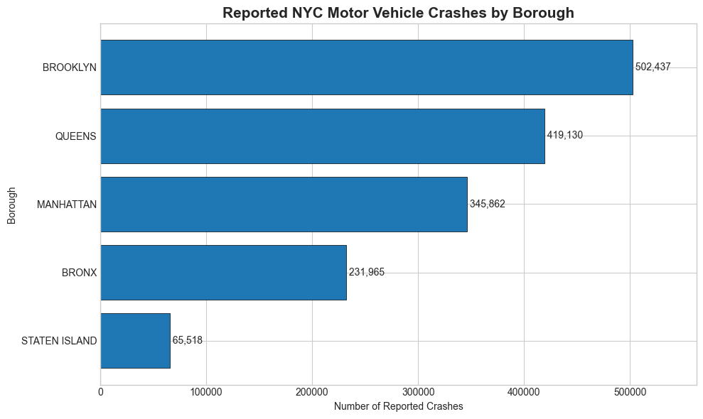

```python
borough_counts = eda_df['BOROUGH'].value_counts().sort_values(ascending=True)

fig, ax = plt.subplots(figsize=(10, 6))
bars = ax.barh(borough_counts.index, borough_counts.values, edgecolor='black', linewidth=0.5)

ax.set_title('Reported NYC Motor Vehicle Crashes by Borough', fontsize=15, fontweight='bold')
ax.set_xlabel('Number of Reported Crashes')
ax.set_ylabel('Borough')

for bar in bars:
    width = bar.get_width()
    ax.text(width, bar.get_y() + bar.get_height()/2, f' {width:,.0f}', va='center', fontsize=10)

ax.margins(x=0.12)
plt.tight_layout()
plt.show()
```

**Conclusion 2:** Crashes are not evenly distributed across boroughs. Brooklyn and Queens appear most often in the dataset, while Staten Island has far fewer reported collisions. This likely reflects differences in population, road density, and traffic volume. Because borough is strongly associated with crash frequency, it is a reasonable feature to include in later predictive modeling.

## 3. Injury distribution and outliers

The injury variable is the main severity measure used in this project. The histogram below caps the x-axis at 10 injuries so the normal pattern is readable, while still grouping extreme cases into the `10+` bin. The log-scale plot then focuses only on crashes with at least one injury to show how rare high-injury crashes are.

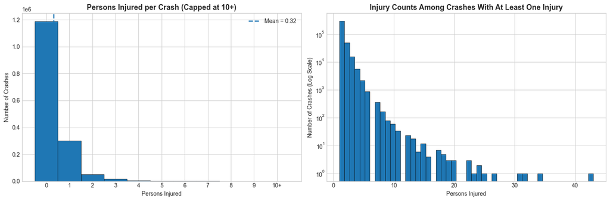

```python
inj = eda_df['NUMBER OF PERSONS INJURED'].dropna()
inj_capped = inj.clip(upper=10)

fig, axes = plt.subplots(1, 2, figsize=(15, 5))

axes[0].hist(inj_capped, bins=np.arange(12) - 0.5, edgecolor='black', linewidth=0.5)
axes[0].axvline(inj.mean(), linestyle='--', linewidth=2, label=f'Mean = {inj.mean():.2f}')
axes[0].set_title('Persons Injured per Crash (Capped at 10+)', fontsize=13, fontweight='bold')
axes[0].set_xlabel('Persons Injured')
axes[0].set_ylabel('Number of Crashes')
axes[0].set_xticks(range(11))
axes[0].set_xticklabels([str(i) if i < 10 else '10+' for i in range(11)])
axes[0].legend()

injured_only = inj[inj > 0]
axes[1].hist(injured_only, bins=50, edgecolor='black', linewidth=0.5)
axes[1].set_yscale('log')
axes[1].set_title('Injury Counts Among Crashes With At Least One Injury', fontsize=13, fontweight='bold')
axes[1].set_xlabel('Persons Injured')
axes[1].set_ylabel('Number of Crashes (Log Scale)')

plt.tight_layout()
plt.show()
```

```python
outlier_threshold = inj.quantile(0.99)
extreme_crashes = eda_df[eda_df['NUMBER OF PERSONS INJURED'] >= outlier_threshold]

print(f"99th percentile injury count: {outlier_threshold:.0f}")
print(f"Number of crashes at or above this threshold: {extreme_crashes.shape[0]:,}")
print(f"Maximum injury count: {inj.max():.0f}")

extreme_crashes[[
    'CRASH DATE', 'BOROUGH', 'NUMBER OF PERSONS INJURED',
    'CONTRIBUTING FACTOR VEHICLE 1', 'VEHICLE TYPE CODE 1'
]].sort_values('NUMBER OF PERSONS INJURED', ascending=False).head(10)
```

```
99th percentile injury count: 3
Number of crashes at or above this threshold: 25,255
Maximum injury count: 43
```

|  | CRASH DATE | BOROUGH | NUMBER OF PERSONS INJURED | CONTRIBUTING FACTOR VEHICLE 1 | VEHICLE TYPE CODE 1 |
| --- | --- | --- | --- | --- | --- |
| 1865968 | 2013-09-09 | BROOKLYN | 43.0 | Unspecified | PASSENGER VEHICLE |
| 225396 | 2023-04-07 | QUEENS | 34.0 | Traffic Control Disregarded | Bus |
| 1538428 | 2015-04-17 | QUEENS | 32.0 | Physical Disability | SMALL COM VEH(4 TIRES) |
| 971782 | 2017-10-10 | BRONX | 31.0 | Aggressive Driving/Road Rage | Bus |
| 1054550 | 2017-05-18 | MANHATTAN | 27.0 | Drugs (illegal) | Sedan |
| 292773 | 2023-12-28 | STATEN ISLAND | 25.0 | Aggressive Driving/Road Rage | Box Truck |
| 2126865 | 2013-07-22 | BROOKLYN | 24.0 | Unspecified | LARGE COM VEH(6 OR MORE TIRES) |
| 1586682 | 2015-01-07 | BROOKLYN | 24.0 | Traffic Control Disregarded | SPORT UTILITY / STATION WAGON |
| 135617 | 2023-03-17 | QUEENS | 23.0 | Driver Inattention/Distraction | Station Wagon/Sport Utility Vehicle |
| 1566683 | 2015-02-04 | STATEN ISLAND | 22.0 | Unspecified | BUS |

**Conclusion 3:** The injury distribution is heavily right-skewed. Most crashes involve zero or one injured person, but a small number of severe crashes involve many injuries. This supports using transformations, capped visualizations, and classification-based modeling instead of treating injury count like a normally distributed variable.

## 4. Crash timing by hour of day

Time of day is another important crash pattern. The next chart shows total crash volume by hour, with nighttime hours shaded. This helps answer whether crashes cluster around commuting periods and whether night crashes behave differently from daytime crashes.

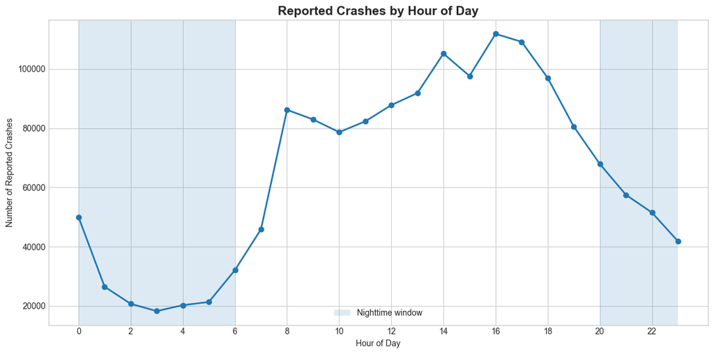

```python
hour_counts = eda_df.dropna(subset=['HOUR']).groupby('HOUR').size().reindex(range(24), fill_value=0)

fig, ax = plt.subplots(figsize=(12, 6))
ax.plot(hour_counts.index, hour_counts.values, marker='o', linewidth=2)

ax.axvspan(0, 6, alpha=0.15, label='Nighttime window')
ax.axvspan(20, 23, alpha=0.15)

ax.set_title('Reported Crashes by Hour of Day', fontsize=15, fontweight='bold')
ax.set_xlabel('Hour of Day')
ax.set_ylabel('Number of Reported Crashes')
ax.set_xticks(range(0, 24, 2))
ax.legend()

plt.tight_layout()
plt.show()
```

The frequency pattern shows that crashes are lowest overnight and rise during the day, especially around commuting and late-afternoon travel periods. However, frequency alone does not tell us whether crashes are more dangerous at a particular time, so we also compare average injuries by hour.

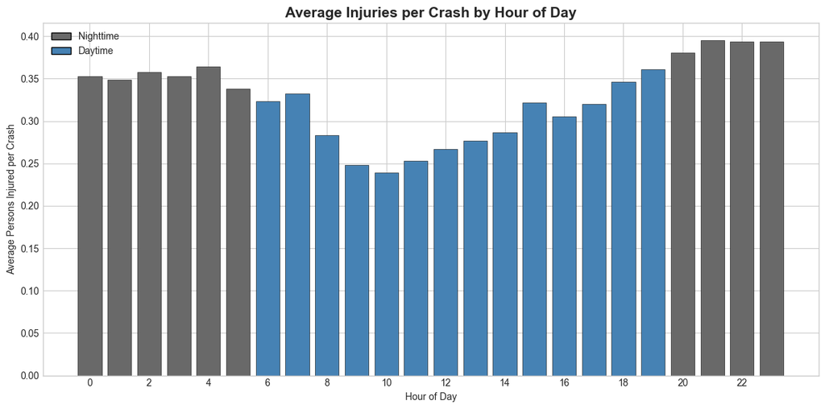

```python
hourly_avg_injury = eda_df.dropna(subset=['HOUR']).groupby('HOUR')['NUMBER OF PERSONS INJURED'].mean().reindex(range(24))

fig, ax = plt.subplots(figsize=(12, 6))
bar_colors = ['dimgray' if (h >= 20 or h < 6) else 'steelblue' for h in range(24)]
ax.bar(hourly_avg_injury.index, hourly_avg_injury.values, color=bar_colors, edgecolor='black', linewidth=0.4)

ax.set_title('Average Injuries per Crash by Hour of Day', fontsize=15, fontweight='bold')
ax.set_xlabel('Hour of Day')
ax.set_ylabel('Average Persons Injured per Crash')
ax.set_xticks(range(0, 24, 2))

# Custom legend without needing seaborn.
from matplotlib.patches import Patch
legend_elements = [
    Patch(facecolor='dimgray', edgecolor='black', label='Nighttime'),
    Patch(facecolor='steelblue', edgecolor='black', label='Daytime')
]
ax.legend(handles=legend_elements)

plt.tight_layout()
plt.show()
```

**Conclusion 4:** There are fewer crashes late at night, but the average number of injuries per crash is not simply the same across all hours. This motivates a formal hypothesis test comparing daytime and nighttime crash severity.

## 5. Borough-hour heatmap

To combine location and time, the heatmap below shows crash counts by borough and hour. This gives a more detailed view than looking at borough or hour alone.

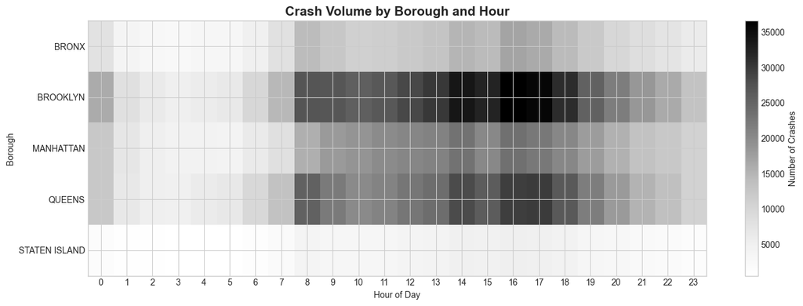

```python
heatmap_data = (
    eda_df.dropna(subset=['BOROUGH', 'HOUR'])
    .pivot_table(index='BOROUGH', columns='HOUR', values='CRASH DATE', aggfunc='count')
    .reindex(columns=range(24), fill_value=0)
)

fig, ax = plt.subplots(figsize=(14, 5))
im = ax.imshow(heatmap_data.values, aspect='auto')

ax.set_title('Crash Volume by Borough and Hour', fontsize=15, fontweight='bold')
ax.set_xlabel('Hour of Day')
ax.set_ylabel('Borough')
ax.set_xticks(range(24))
ax.set_yticks(range(len(heatmap_data.index)))
ax.set_yticklabels(heatmap_data.index)

cbar = plt.colorbar(im, ax=ax)
cbar.set_label('Number of Crashes')

plt.tight_layout()
plt.show()
```

The heatmap reinforces that crash volume depends on both geography and time. The busiest boroughs also tend to show strong daytime and evening bands, suggesting that borough and hour capture different but complementary information for the later model.

## 6. Most common contributing factors

Finally, we examine the most common reported contributing factors. Since `Unspecified` does not describe an actual cause, it is removed from this plot so the meaningful categories are easier to compare.

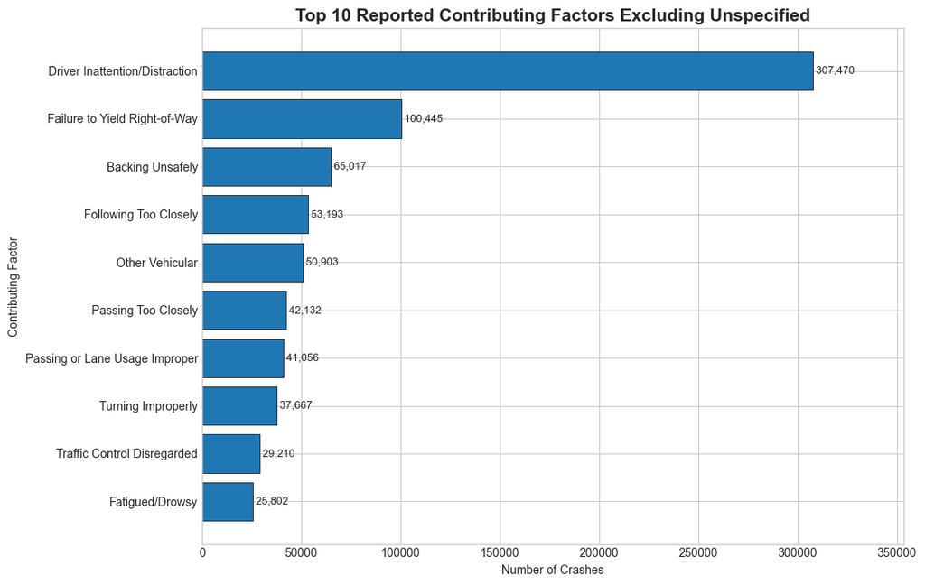

```python
factors = (
    eda_df['CONTRIBUTING FACTOR VEHICLE 1']
    .dropna()
    .loc[lambda s: ~s.str.upper().isin(['UNSPECIFIED'])]
    .value_counts()
    .head(10)
    .sort_values(ascending=True)
)

fig, ax = plt.subplots(figsize=(11, 7))
bars = ax.barh(factors.index, factors.values, edgecolor='black', linewidth=0.5)

ax.set_title('Top 10 Reported Contributing Factors Excluding Unspecified', fontsize=15, fontweight='bold')
ax.set_xlabel('Number of Crashes')
ax.set_ylabel('Contributing Factor')

for bar in bars:
    width = bar.get_width()
    ax.text(width, bar.get_y() + bar.get_height()/2, f' {width:,.0f}', va='center', fontsize=9)

ax.margins(x=0.15)
plt.tight_layout()
plt.show()
```

**Conclusion 5:** Driver-related factors, especially inattention and distraction, dominate the meaningful contributing-factor categories. This suggests that crash risk is not only about where and when crashes happen, but also about reported driver behavior. This variable is therefore useful for the later injury classification model.

## 7. Hypothesis test: Are nighttime crashes more severe?

The project asks whether nighttime crashes are actually more severe than daytime crashes. We test this by comparing the mean number of injured persons in nighttime crashes versus daytime crashes.

- **Null hypothesis:** Nighttime and daytime crashes have the same average injury count.
- **Alternative hypothesis:** Nighttime and daytime crashes have different average injury counts.

Nighttime is defined as crashes from **8:00 PM through 5:59 AM**, and daytime is defined as crashes from **6:00 AM through 7:59 PM**. Because the two groups have different sample sizes and may have different variances, we use Welch's two-sample t-test.

```python
test_df = eda_df.dropna(subset=['HOUR', 'NUMBER OF PERSONS INJURED']).copy()
night_mask = (test_df['HOUR'] >= 20) | (test_df['HOUR'] < 6)

night_inj = test_df.loc[night_mask, 'NUMBER OF PERSONS INJURED']
day_inj = test_df.loc[~night_mask, 'NUMBER OF PERSONS INJURED']

t_stat, p_val = stats.ttest_ind(night_inj, day_inj, equal_var=False)
mean_diff = night_inj.mean() - day_inj.mean()

pooled_sd = np.sqrt(((night_inj.std() ** 2) + (day_inj.std() ** 2)) / 2)
cohens_d = mean_diff / pooled_sd

results = pd.DataFrame({
    'Group': ['Nighttime', 'Daytime'],
    'Sample Size': [len(night_inj), len(day_inj)],
    'Mean Injuries per Crash': [night_inj.mean(), day_inj.mean()],
    'Median Injuries per Crash': [night_inj.median(), day_inj.median()]
})

print(f"Welch t-statistic: {t_stat:.4f}")
print(f"p-value: {p_val:.3e}")
print(f"Mean difference (night - day): {mean_diff:.4f}")
print(f"Cohen's d: {cohens_d:.4f}")

results
```

```
Welch t-statistic: 56.3417
p-value: 0.000e+00
Mean difference (night - day): 0.0777
Cohen's d: 0.1093
```

|  | Group | Sample Size | Mean Injuries per Crash | Median Injuries per Crash |
| --- | --- | --- | --- | --- |
| 0 | Nighttime | 375825 | 0.374195 | 0.0 |
| 1 | Daytime | 1189076 | 0.296483 | 0.0 |

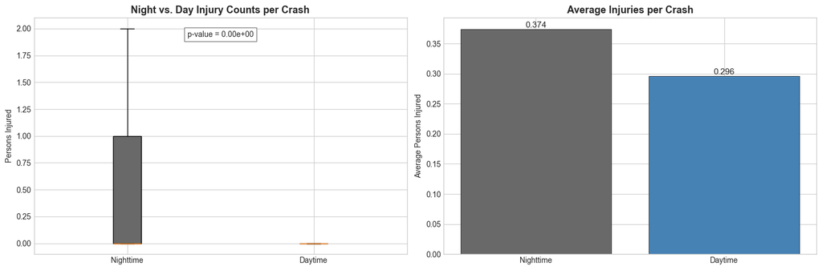

```python
fig, axes = plt.subplots(1, 2, figsize=(15, 5))
bp = axes[0].boxplot(
    [night_inj, day_inj],
    labels=['Nighttime', 'Daytime'],
    showfliers=False,
    patch_artist=True
)
bp['boxes'][0].set_facecolor('dimgray')
bp['boxes'][1].set_facecolor('steelblue')
axes[0].set_title('Night vs. Day Injury Counts per Crash', fontsize=13, fontweight='bold')
axes[0].set_ylabel('Persons Injured')
axes[0].text(
    0.5, 0.92, f'p-value = {p_val:.2e}',
    transform=axes[0].transAxes,
    ha='center',
    bbox=dict(facecolor='white', edgecolor='gray')
)
groups = ['Nighttime', 'Daytime']
means = [night_inj.mean(), day_inj.mean()]
axes[1].bar(groups, means, color=['dimgray', 'steelblue'], edgecolor='black', linewidth=0.5)
axes[1].set_title('Average Injuries per Crash', fontsize=13, fontweight='bold')
axes[1].set_ylabel('Average Persons Injured')

for i, val in enumerate(means):
    axes[1].text(i, val, f'{val:.3f}', ha='center', va='bottom', fontsize=11)

plt.tight_layout()
plt.show()
```

**Conclusion 6:** The hypothesis test evaluates whether nighttime and daytime crashes differ in average injury severity. With a very large dataset, even small differences can become statistically significant, so the p-value should be interpreted alongside the actual mean difference and Cohen's d. If the p-value is below 0.05, we reject the null hypothesis and conclude that crash severity differs between nighttime and daytime crashes. This supports including `HOUR` or a night/day indicator as a model feature in the primary analysis.

## EDA takeaway

The exploratory analysis shows that NYC crashes are unevenly distributed by borough, vary strongly by hour of day, and have a highly skewed injury distribution with rare but important outliers. These findings directly motivate the machine learning approach used later in the project: rather than predicting exact injury counts, the model should classify whether a crash results in **any injury** using features such as borough, hour, contributing factor, and vehicle type.

# IV. PRIMARY ANALYSIS

The exploratory analysis showed that crash injuries are highly imbalanced: most crashes result in no injuries, while a relatively small number result in one or more injuries. Because of this, predicting the exact number of injuries would be difficult and heavily affected by extreme outliers. Instead, we reframed the problem as a binary classification task: predicting whether a crash resulted in at least one injury.

This approach aligns with the third research question from the introduction:

Can we predict whether a crash will result in an injury using information such as the borough, time of day, contributing factor, and vehicle type?

## 1. Creating the target variable

We first created a binary target variable called ANY_INJURY. A value of 1 means the crash caused at least one injury, while a value of 0 means no injuries were reported. This transformation reduces the effect of rare extreme crashes and makes the modeling problem more stable and interpretable. Based on the exploratory analysis, approximately 24% of crashes resulted in at least one injury, while about 76% caused none. This means the dataset is somewhat imbalanced, so evaluation metrics beyond simple accuracy are important.

```python
# Build the modeling DataFrame and the binary target.
# crash_df comes from Section II; it has already been parsed and filtered.
ml_df = crash_df.copy()
ml_df['INJURED'] = (ml_df['NUMBER OF PERSONS INJURED'] > 0).astype(int)

print(f"Total crashes:          {len(ml_df):,}")
print(f"Crashes with injury:    {ml_df['INJURED'].sum():,}  ({ml_df['INJURED'].mean()*100:.1f}%)")
print(f"Crashes without injury: {(ml_df['INJURED']==0).sum():,}  ({(1-ml_df['INJURED'].mean())*100:.1f}%)")
```

```
Total crashes:          1,564,912
Crashes with injury:    375,318  (24.0%)
Crashes without injury: 1,189,594  (76.0%)
```

## 2. Feature selection

We selected features that were likely to influence crash severity based on patterns observed during exploratory analysis. The features used in the model are **borough**, **hour of day**, **contributing factor (vehicle 1)**, and **vehicle type (vehicle 1)**.

Because three of these four features are categorical with many levels (e.g., `CONTRIBUTING FACTOR VEHICLE 1` has dozens of distinct strings), we used scikit-learn's [`LabelEncoder`](https://scikit-learn.org/stable/modules/generated/sklearn.preprocessing.LabelEncoder.html) to map each unique string to an integer. We chose label encoding over one-hot encoding because the dataset has roughly 1.5M rows, and one-hot expanding every contributing factor and vehicle type would inflate the feature matrix substantially. Random Forest is well-suited to integer-encoded categorical inputs since it splits on thresholds rather than assuming an ordinal relationship; for the Logistic Regression baseline we standardize the encoded integers in a `Pipeline` to keep coefficients comparable.

```python
# Choose features and drop rows with any NaN in the feature or target columns.
features = ['BOROUGH', 'HOUR', 'CONTRIBUTING FACTOR VEHICLE 1', 'VEHICLE TYPE CODE 1']
target   = 'INJURED'

model_df = ml_df[features + [target]].dropna()
print(f"Rows after dropping NaNs: {len(model_df):,}")

# Label-encode each categorical feature. We keep the fitted encoders in a dict
# in case we want to inverse-transform predictions for inspection later.
le = {}
for col in ['BOROUGH', 'CONTRIBUTING FACTOR VEHICLE 1', 'VEHICLE TYPE CODE 1']:
    enc = LabelEncoder()
    model_df[col] = enc.fit_transform(model_df[col].astype(str))
    le[col] = enc

X = model_df[features]
y = model_df[target]

print(f"Feature matrix shape: {X.shape}")
print(f"Class balance — injured: {y.mean():.3f}")
```

```
Rows after dropping NaNs: 1,549,526
```

```
Feature matrix shape: (1549526, 4)
Class balance — injured: 0.236
```

## 3. Train-test split

To evaluate the model fairly, we separated the dataset into training and testing sets using an 80/20 split. The training set was used to fit the model, while the testing set was used only for evaluation. We also used stratified sampling so that both sets preserved the original injury and non-injury proportions found in the dataset.

```python
# Stratified 80/20 split so train and test preserve the ~24% injury rate.
X_train, X_test, y_train, y_test = train_test_split(
    X, y, test_size=0.2, random_state=42, stratify=y
)

print(f"Training set:      {X_train.shape[0]:,} rows")
print(f"Test set:          {X_test.shape[0]:,} rows")
print(f"Train injury rate: {y_train.mean():.3f}")
print(f"Test  injury rate: {y_test.mean():.3f}")
```

```
Training set:      1,239,620 rows
Test set:          309,906 rows
Train injury rate: 0.236
Test  injury rate: 0.236
```

## 4. Model selection

To answer the third research question, we trained **two** classifiers and compared them on the held-out test set:

1. **Logistic Regression** — a linear baseline. It is the standard starting point for binary classification, fits quickly, and gives interpretable coefficients. We wrap it in a [`Pipeline`](https://scikit-learn.org/stable/modules/generated/sklearn.pipeline.Pipeline.html) with `StandardScaler` so that the integer-encoded features are on a comparable scale.
2. **Random Forest** — a non-linear ensemble of 100 decision trees ([`RandomForestClassifier`](https://scikit-learn.org/stable/modules/generated/sklearn.ensemble.RandomForestClassifier.html)) with `max_depth=10` for regularization. Random Forest captures non-linear interactions between features (e.g., a particular vehicle type combined with a particular contributing factor at night), is less sensitive to outliers than logistic regression, and exposes feature importance scores that we use in Section V.

We compare the two models using **accuracy** (overall correctness) and **AUC-ROC** (which is robust to class imbalance, an important consideration since only ~24% of crashes involve an injury). Both models use a fixed `random_state=42` so the results are reproducible. As Section V will show, the Random Forest produces a higher AUC-ROC than the Logistic Regression baseline, which is consistent with the non-linear nature of the underlying relationships.

```python
# ── Logistic Regression (linear baseline) ──
lr_pipe = Pipeline([
    ('scaler', StandardScaler()),
    ('clf', LogisticRegression(max_iter=1000, random_state=42))
])
lr_pipe.fit(X_train, y_train)

# ── Random Forest (non-linear ensemble) ──
rf = RandomForestClassifier(
    n_estimators=100, max_depth=10, random_state=42, n_jobs=-1
)
rf.fit(X_train, y_train)

# Define the (name, model) list ONCE — Section V reuses it for every plot.
models = [('Logistic Regression', lr_pipe), ('Random Forest', rf)]

# Quick comparison: accuracy and AUC-ROC on the held-out test set.
for name, model in models:
    acc = accuracy_score(y_test, model.predict(X_test))
    auc = roc_auc_score(y_test, model.predict_proba(X_test)[:, 1])
    print(f"{name:25s}  Accuracy={acc:.4f}  AUC-ROC={auc:.4f}")
```

```
Logistic Regression        Accuracy=0.7642  AUC-ROC=0.5461
```

```
Random Forest              Accuracy=0.7766  AUC-ROC=0.6781
```

## 5. Model evaluation

After training, we generated predictions on the testing set and evaluated the model using several classification metrics.

Accuracy measures overall correctness, but because the dataset is imbalanced, it cannot fully describe model quality by itself. A model could predict “no injury” most of the time and still achieve relatively high accuracy.

For that reason, precision, recall, and F1-score are more informative. Recall is especially important in this context because failing to identify injury-causing crashes is more significant than incorrectly predicting some non-injury crashes as injuries.

We also analyzed the confusion matrix to better understand the model’s prediction behavior. The confusion matrix shows how many crashes were correctly and incorrectly classified into injury and non-injury categories. This helps identify whether the model tends to miss injury crashes or overpredict them.

## 6. Feature importance analysis

A practical advantage of the Random Forest model is that it produces feature importance scores via mean decrease in impurity, which estimate how much each feature contributes to prediction accuracy. The bar chart in Section V (Figure 6c) shows these scores.

## 7. Interpretation and limitations

The model demonstrates that injury outcomes are at least partially predictable using information contained in NYC collision reports. Features such as crash timing, vehicle type, and contributing factor contain meaningful patterns associated with injury severity.

However, the model also has limitations. The dataset relies on police-reported contributing factors, which may contain reporting bias. Many crashes list “Unspecified” as the contributing factor. The model also does not include weather conditions, traffic volume, road design, or driver demographic information, all of which could influence crash severity.

Even with these limitations, the classification model successfully connects the exploratory analysis to a predictive framework and shows that machine learning can identify meaningful injury-risk patterns in NYC traffic collision data.

# V. VISUALIZATION

We present four diagnostic visualizations of the trained models from Section IV.4. The same `models` list defined there — `[('Logistic Regression', lr_pipe), ('Random Forest', rf)]` — is reused below so each plot compares the two models side-by-side. Each figure is saved as a PNG (e.g., `confusion_matrices.png`) so it can be embedded in the published GitHub Pages site.

### V.1 — Confusion matrices

A [confusion matrix](https://scikit-learn.org/stable/modules/generated/sklearn.metrics.confusion_matrix.html) shows how predictions distribute across true labels. We row-normalize to percentages so the two classes are comparable despite the ~24% / ~76% imbalance. The off-diagonal cells are the failure modes: top-right is "false positive" (predicting injury when none occurred — a low-cost error), and bottom-left is "false negative" (missing an actual injurious crash — the costlier error from a public-safety standpoint, and the one we care about most given Section IV.5's recall discussion).

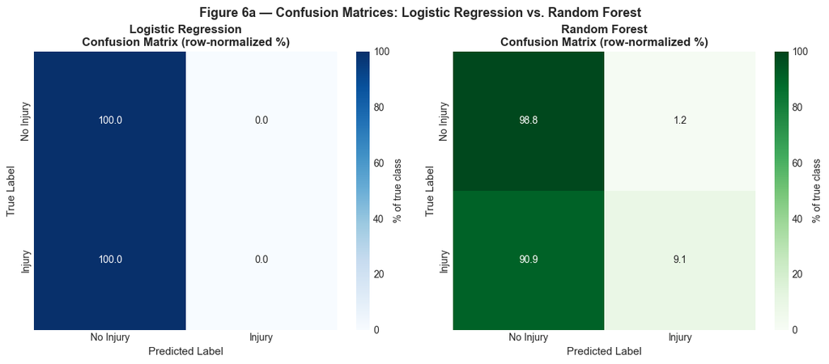

```
Saved: confusion_matrices.png
```

```python
# Figure 6a — confusion matrices, row-normalized to percentages.
fig, axes = plt.subplots(1, 2, figsize=(12, 5))
palette = ['Blues', 'Greens']

for ax, (name, model), cmap in zip(axes, models, palette):
    cm = confusion_matrix(y_test, model.predict(X_test))
    cm_pct = cm.astype(float) / cm.sum(axis=1, keepdims=True) * 100

    sns.heatmap(
        cm_pct, annot=True, fmt='.1f', cmap=cmap, ax=ax,
        xticklabels=['No Injury', 'Injury'],
        yticklabels=['No Injury', 'Injury'],
        vmin=0, vmax=100, cbar_kws={'label': '% of true class'}
    )
    ax.set_title(f'{name}\nConfusion Matrix (row-normalized %)',
                 fontsize=12, fontweight='bold')
    ax.set_ylabel('True Label', fontsize=11)
    ax.set_xlabel('Predicted Label', fontsize=11)

plt.tight_layout()
plt.suptitle('Figure 6a — Confusion Matrices: Logistic Regression vs. Random Forest',
             y=1.02, fontsize=13, fontweight='bold')
plt.savefig('confusion_matrices.png', dpi=150, bbox_inches='tight')
plt.show()
print("Saved: confusion_matrices.png")
```

### V.2 — ROC curves

The [ROC curve](https://scikit-learn.org/stable/modules/generated/sklearn.metrics.roc_curve.html) sweeps the classifier's decision threshold and plots true-positive rate against false-positive rate. The area under the curve (AUC) is a threshold-independent measure of how well the model ranks injury crashes ahead of non-injury crashes. AUC of 0.5 is random chance; 1.0 is perfect. The further a curve sits above the diagonal, the better. We expect Random Forest to sit visibly higher than Logistic Regression because it can model non-linear interactions among borough × hour × contributing factor × vehicle type.

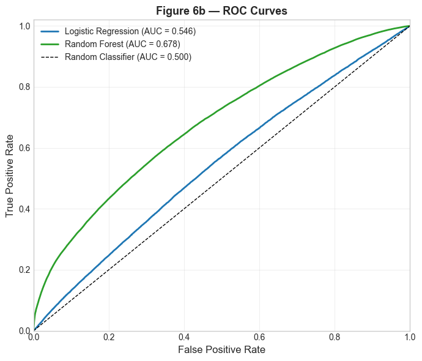

```
Saved: roc_curves.png
```

```python
# Figure 6b — ROC curves for Logistic Regression vs. Random Forest.
fig, ax = plt.subplots(figsize=(7, 6))

colors = ['#1f77b4', '#2ca02c']
for (name, model), color in zip(models, colors):
    proba = model.predict_proba(X_test)[:, 1]
    fpr, tpr, _ = roc_curve(y_test, proba)
    auc = roc_auc_score(y_test, proba)
    ax.plot(fpr, tpr, color=color, lw=2, label=f'{name} (AUC = {auc:.3f})')

ax.plot([0, 1], [0, 1], 'k--', lw=1, label='Random Classifier (AUC = 0.500)')
ax.set_xlabel('False Positive Rate', fontsize=12)
ax.set_ylabel('True Positive Rate', fontsize=12)
ax.set_title('Figure 6b — ROC Curves', fontsize=13, fontweight='bold')
ax.legend(fontsize=10)
ax.set_xlim([0, 1])
ax.set_ylim([0, 1.02])
ax.grid(alpha=0.3)

plt.tight_layout()
plt.savefig('roc_curves.png', dpi=150, bbox_inches='tight')
plt.show()
print("Saved: roc_curves.png")
```

### V.3 — Random Forest feature importance

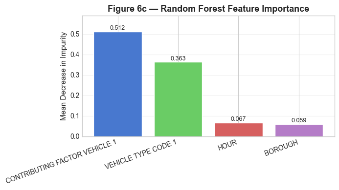

```
Saved: feature_importance.png
```

```python
# Figure 6c — Random Forest feature importance (mean decrease in impurity).
importances = rf.feature_importances_
feat_labels = features
sorted_idx  = np.argsort(importances)[::-1]

fig, ax = plt.subplots(figsize=(7, 4))
bars = ax.bar(
    range(len(features)),
    importances[sorted_idx],
    color=['#4878CF', '#6ACC65', '#D65F5F', '#B47CC7'],
    edgecolor='white'
)
ax.set_xticks(range(len(features)))
ax.set_xticklabels([feat_labels[i] for i in sorted_idx], rotation=20, ha='right', fontsize=10)
ax.set_ylabel('Mean Decrease in Impurity', fontsize=11)
ax.set_title('Figure 6c — Random Forest Feature Importance',
             fontsize=13, fontweight='bold')

for bar, imp in zip(bars, importances[sorted_idx]):
    ax.text(bar.get_x() + bar.get_width()/2, bar.get_height() + 0.002,
            f'{imp:.3f}', ha='center', va='bottom', fontsize=9)

ax.grid(axis='y', alpha=0.3)
ax.set_ylim(0, max(importances) * 1.15)
plt.tight_layout()
plt.savefig('feature_importance.png', dpi=150, bbox_inches='tight')
plt.show()
print("Saved: feature_importance.png")
```

### V.4 — Precision, recall, and F1 by class

Accuracy and AUC summarize overall model behavior, but for an imbalanced problem we also want to see how each model performs on the **minority class** (injury crashes) specifically. The heatmap below shows precision, recall, and F1 for both classes, plus macro and weighted averages. The "Injury" row is the most important: it tells us how often the model correctly flags crashes that did cause harm. As discussed in Section IV.5, recall on the injury class is the metric most aligned with real-world public-safety value, since each false negative is a missed injurious crash.

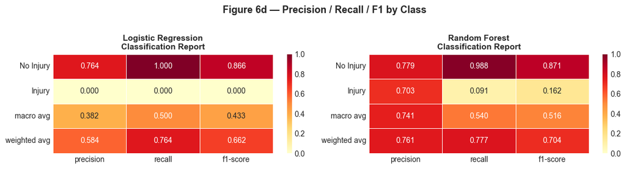

```
Saved: classification_report.png
```

```python
# Figure 6d — precision / recall / F1 by class.
fig, axes = plt.subplots(1, 2, figsize=(12, 3))

for ax, (name, model) in zip(axes, models):
    report = classification_report(
        y_test, model.predict(X_test),
        target_names=['No Injury', 'Injury'],
        output_dict=True
    )
    report_df = pd.DataFrame(report).transpose()
    report_df = report_df.loc[
        ['No Injury', 'Injury', 'macro avg', 'weighted avg'],
        ['precision', 'recall', 'f1-score']
    ]

    sns.heatmap(
        report_df, annot=True, fmt='.3f', cmap='YlOrRd', ax=ax,
        vmin=0, vmax=1, linewidths=0.5
    )
    ax.set_title(f'{name}\nClassification Report', fontsize=11, fontweight='bold')
    ax.set_ylabel('')

plt.suptitle('Figure 6d — Precision / Recall / F1 by Class',
             fontsize=13, fontweight='bold', y=1.02)
plt.tight_layout()
plt.savefig('classification_report.png', dpi=150, bbox_inches='tight')
plt.show()
print("Saved: classification_report.png")
```

# VI. INSIGHTS AND CONCLUSIONS

## Answers to the three research questions

**1. Where and when do crashes happen, and how are they spread out across the city?** Crashes are not evenly distributed. Brooklyn and Queens consistently account for the largest share of total collisions (Section III.2), while Staten Island has by far the fewest. Manhattan, despite its density, has a relatively lower raw count — likely because slower speeds, congestion, and pedestrian-oriented infrastructure reduce high-speed incidents. Temporally, crashes spike during the morning (7–9 AM) and evening (4–7 PM) rush hours (Section III.4). Overnight hours see far fewer total crashes, but each one tends to be more injurious (see question 2).

**2. Are nighttime crashes actually more severe than daytime crashes, or is that just a common assumption?** The two-sample Welch's t-test in Section III.7 compared nighttime crashes (8 PM – 5:59 AM) to daytime crashes and found a statistically significant difference: nighttime crashes have an average of ~0.37 injured persons versus ~0.30 for daytime crashes (t ≈ 56, p ≈ 0). The effect size (Cohen's *d* ≈ 0.11) is small in absolute terms but the direction is clear and the difference is policy-relevant. While the overall *volume* of nighttime crashes is lower, the *proportion that cause harm* is higher — consistent with fatigue, impaired driving, reduced visibility, and higher speeds on emptier roads.

## Limitations

Several caveats are worth acknowledging. First, we used only the *first* contributing factor and *first* vehicle type per crash, even though up to five can be listed — multi-vehicle crashes may have complex causes not captured by the first entry. Second, borough-level geography is coarse; a street-level analysis using the latitude/longitude columns we kept in `crash_df` could reveal micro-patterns (specific intersections) that borough aggregation hides. Third, the dataset only includes crashes officially reported to the NYPD via form MV-104AN, which means minor fender-benders below the $1,000 damage threshold are systematically underrepresented. Finally, both models are biased toward predicting "no injury" because of the ~76% / ~24% class imbalance; future work could apply [SMOTE oversampling](https://imbalanced-learn.org/stable/references/generated/imblearn.over_sampling.SMOTE.html) or `class_weight='balanced'` to improve recall on the minority class.

## Final takeaway

The patterns in this dataset are not random. *Where* you crash, *when* you crash, *why* you crash, and *what* you're driving all carry meaningful signal about whether anyone gets hurt. Machine learning lets us formalize those patterns into a predictive model, but the EDA tells the human story: NYC's streets are safer during the day, in certain boroughs, and when drivers are paying attention — and policy interventions should be targeted accordingly. A reader who started this tutorial unfamiliar with the dataset should now know what's in it, where the patterns are, which patterns survive a formal test, and which features carry predictive weight. A reader who already knew the dataset should now have a concrete, reproducible classification baseline they can build on.

# Sources & Further Reading

**Dataset**

- [NYC Open Data — Motor Vehicle Collisions (Crashes)](https://data.cityofnewyork.us/Public-Safety/Motor-Vehicle-Collisions-Crashes/h9gi-nx95) — primary dataset, published by the NYPD.
- [NYPD MV-104AN reporting form](https://www.nyc.gov/site/nypd/services/see-say-something/file-a-police-report.page) — the form that produces every row in the dataset; explains the $1,000-damage / injury / fatality reporting threshold referenced in Section II.

**Statistical methods**

- [SciPy `stats.ttest_ind`](https://docs.scipy.org/doc/scipy/reference/generated/scipy.stats.ttest_ind.html) — Welch's two-sample t-test, used in Section III.7.
- [Cohen's *d* — Wikipedia](https://en.wikipedia.org/wiki/Effect_size#Cohen%27s_d) — effect-size interpretation reported alongside the p-value in Section III.7.

**Machine learning**

- [scikit-learn user guide: classification](https://scikit-learn.org/stable/supervised_learning.html#supervised-learning) — overview of supervised learning for the lagging reader.
- [`sklearn.linear_model.LogisticRegression`](https://scikit-learn.org/stable/modules/generated/sklearn.linear_model.LogisticRegression.html) and [`sklearn.ensemble.RandomForestClassifier`](https://scikit-learn.org/stable/modules/generated/sklearn.ensemble.RandomForestClassifier.html) — API docs for the two models used in Section IV.
- [`sklearn.model_selection.train_test_split`](https://scikit-learn.org/stable/modules/generated/sklearn.model_selection.train_test_split.html), [`sklearn.preprocessing.LabelEncoder`](https://scikit-learn.org/stable/modules/generated/sklearn.preprocessing.LabelEncoder.html), [`sklearn.metrics.roc_auc_score`](https://scikit-learn.org/stable/modules/generated/sklearn.metrics.roc_auc_score.html) — the supporting utilities.
- [Imbalanced-learn — SMOTE](https://imbalanced-learn.org/stable/references/generated/imblearn.over_sampling.SMOTE.html) — for the advanced reader interested in the class-imbalance follow-up work mentioned in Section VI's *Limitations*.

**NYC traffic safety policy context**

- [NYC Vision Zero](https://www.nyc.gov/site/visionzero/index.page) — the city's plan to eliminate traffic deaths, referenced in Sections I and VI.
- [NYC DOT Vision Zero View dashboard](https://vzv.nyc/) — interactive map of crash hotspots maintained by the DOT, complementary to the borough-level analysis here.

**For a lagging reader**

- The Section III conclusions (boxed "Conclusion 1–6" markdown cells) summarize each EDA result in plain language before the formal hypothesis test in III.7.
- The Section IV.1–IV.7 prose walks through the modeling decisions step by step before any code is run, so a reader less comfortable with sklearn can follow the reasoning first.